# Homework_2_Cuesta

## R Markdown

### Excersises 3.4.2

[figure not shown]

```r
library(ggplot2)
ggplot(data = mpg)
```

### How many rows are in mpg? How many columns?

234 rows, 11 columns

### What does the drv variable describe? Read the help for ?mpg to find out.

f = front-wheel drive, r = rear wheel drive, 4 = 4wd

### Make a scatterplot of hwy vs cyl.

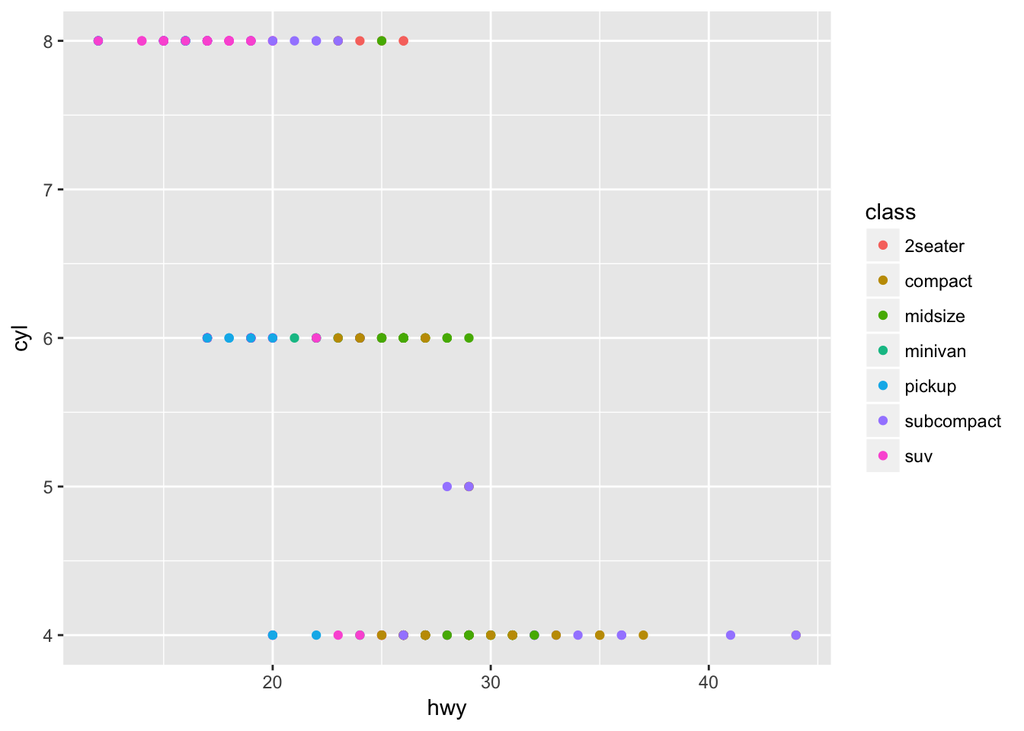

```r
ggplot(data = mpg) +
  geom_point(mapping = aes(x = hwy, y = cyl, color = class))
```

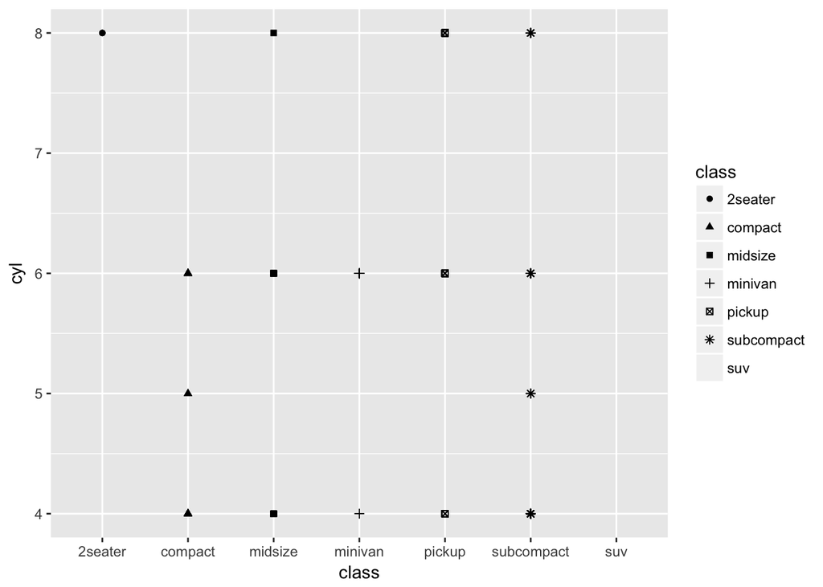

```r
library(ggplot2)
ggplot(data = mpg) +
  geom_point(mapping = aes(x = class, y = cyl, shape = class))
```

# 3.3.1

### What’s gone wrong with this code? Why are the points not blue?

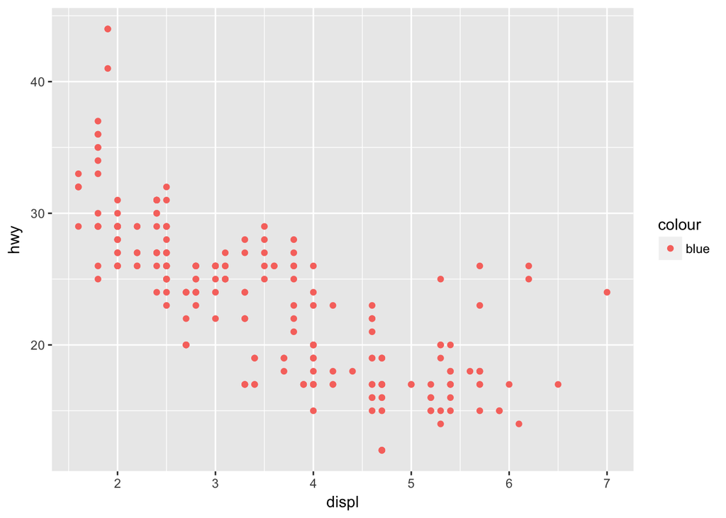

```r
ggplot(data = mpg) +
  geom_point(mapping = aes(x = displ, y = hwy, color = "blue"))
```

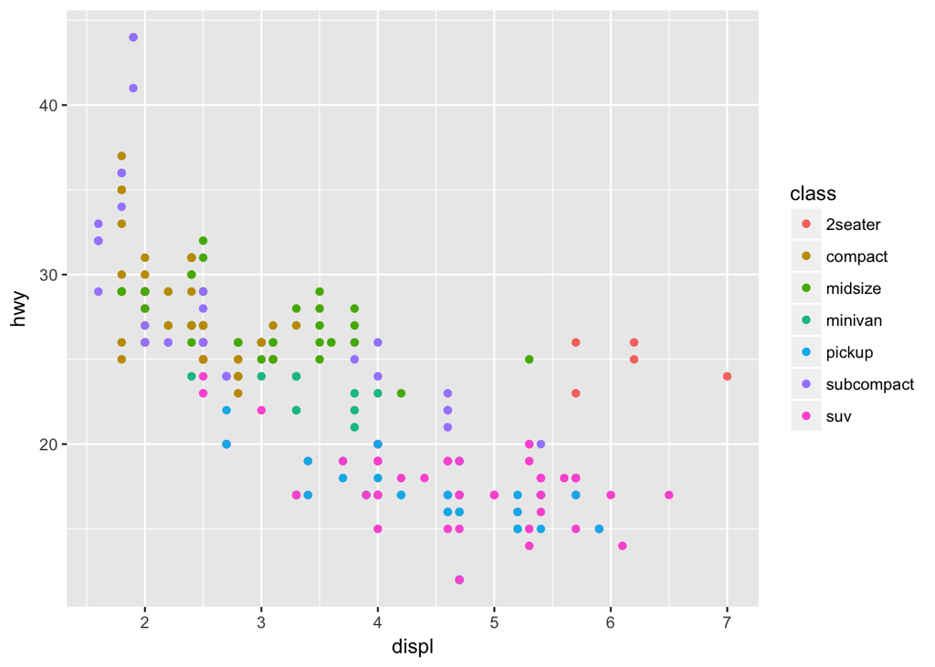

```r
ggplot(data = mpg) +
  geom_point(mapping = aes(x = displ, y = hwy, color = class))
```

### Which variables in mpg are categorical? Which variables are continuous? (Hint: type ?mpg to read the documentation for the dataset). How can you see this information when you run mpg?

The following variables are continous: Displ, year, cty, hwy

### Map a continuous variable to color, size, and shape. How do these aesthetics behave differently for categorical vs. continuous variables?

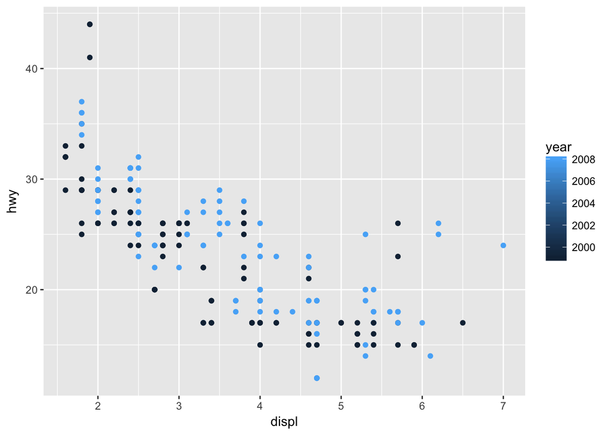

```r
ggplot(data = mpg) +
  geom_point(mapping = aes(x = displ, y = hwy, color = year))
```

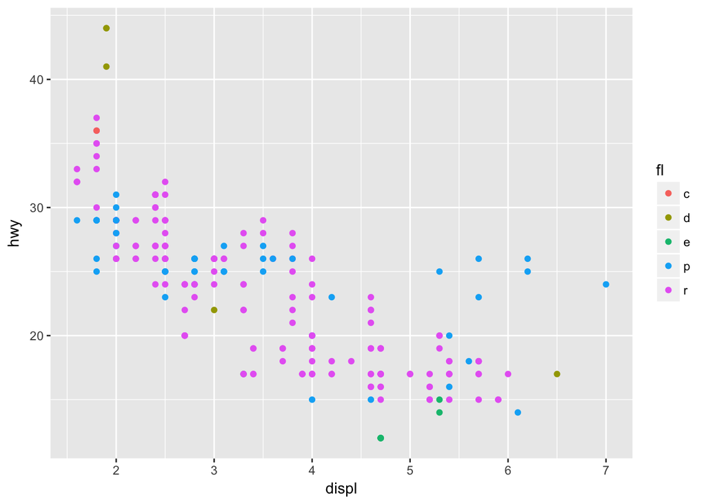

```r
ggplot(data = mpg) +
  geom_point(mapping = aes(x = displ, y = hwy, color = fl))
```

### What happens if you map the same variable to multiple aesthetics?

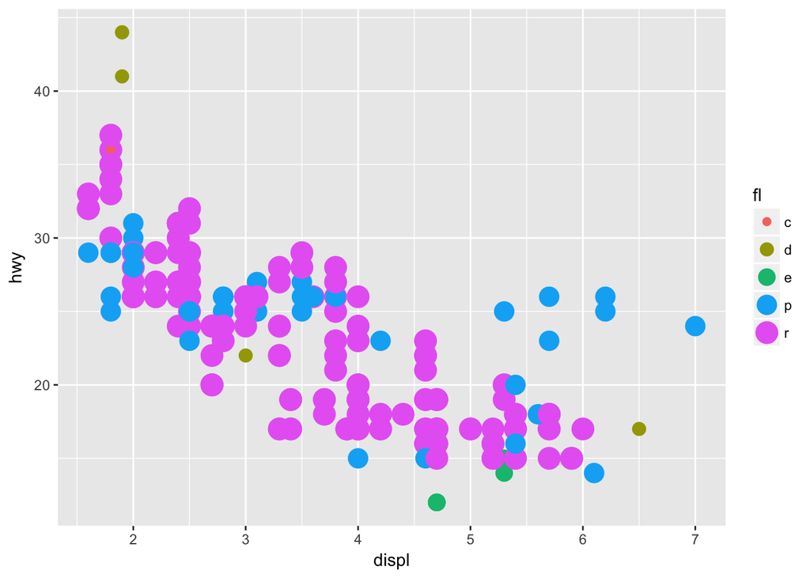

```r
ggplot(data = mpg) +
  geom_point(mapping = aes(x = displ, y = hwy, color = fl, size=fl))
```

### What does the stroke aesthetic do? What shapes does it work with? (Hint: use ?geom_point)

the stroke aesthetic modifies the width of the border. It works Only shapes with ‘pch’ between 21 and 25.hose shapes which have borders are the only ones that stroke can alter.

### What happens if you map an aesthetic to something other than a variable name, like aes(colour = displ < 5)?

gplot turns displ < 5 into a boolean (or dummy) variable on the fly and maps that T or F to the colour argument.

### Section 3.5.1: #4 and #5 only

#### Take the first faceted plot in this section:

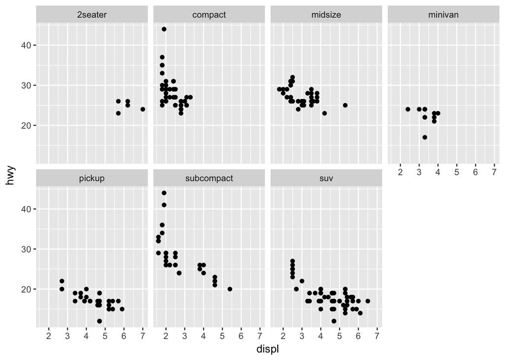

```r
ggplot(data = mpg) +
  geom_point(mapping = aes(x = displ, y = hwy)) +
  facet_wrap(~ class, nrow = 2)
```

#### What are the advantages to using faceting instead of the colour aesthetic? What are the disadvantages? How might the balance change if you had a larger dataset?

facetting is much better to pay particular attention to particular facets alone and the color aesthetic is better to detailed which points are located where.

#### Read ?facet_wrap. What does nrow do? What does ncol do? What other options control the layout of the individual panels? Why doesn’t facet_grid() have nrow and ncol argument?

nrow controls the number of rows for the total number of facets whereas ncol controls the number of columns. Other options can control interesting parameters. The function also has the labeller option to change the names of each facet and other options like strip.position for the position of the facets labels. Read ?facet_wrap for more options.

### Section 3.6.1: #1-5.

#### What geom would you use to draw a line chart? A boxplot? A histogram? An area chart?

geom_line() to draw a line geom_boxplot() to draw a boxplot geom_histogram(bins = 60) to draw a histogram geom_area() to draw an aera chart

#### Run this code in your head and predict what the output will look like. Then, run the code in R and check your predictions.

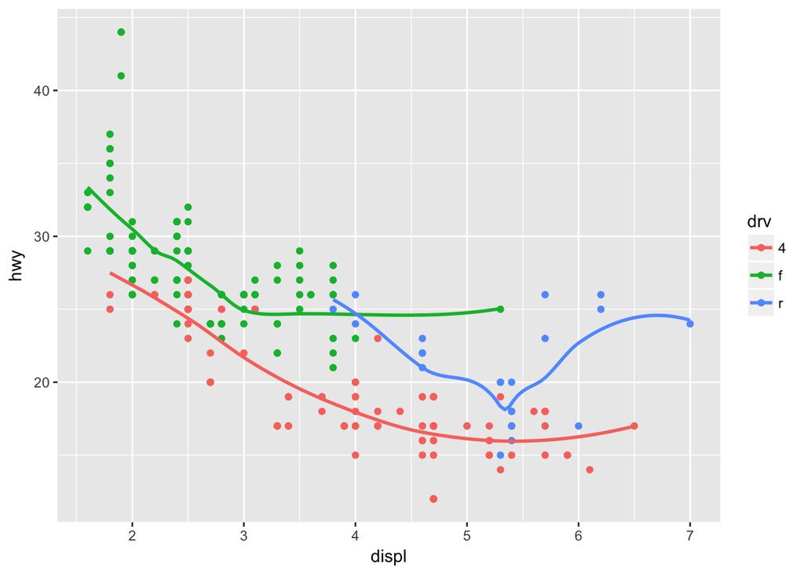

```r
ggplot(data = mpg, mapping = aes(x = displ, y = hwy, color = drv)) +
  geom_point() +
  geom_smooth(se = FALSE)
```

#### What does show.legend = FALSE do? What happens if you remove it? Why do you think I used it earlier in the chapter?

It removes the legend.

### What does the se argument to geom_smooth() do?

It removes the confidence intervals from the smoothed lines

#### Will these two graphs look different? Why/why not?

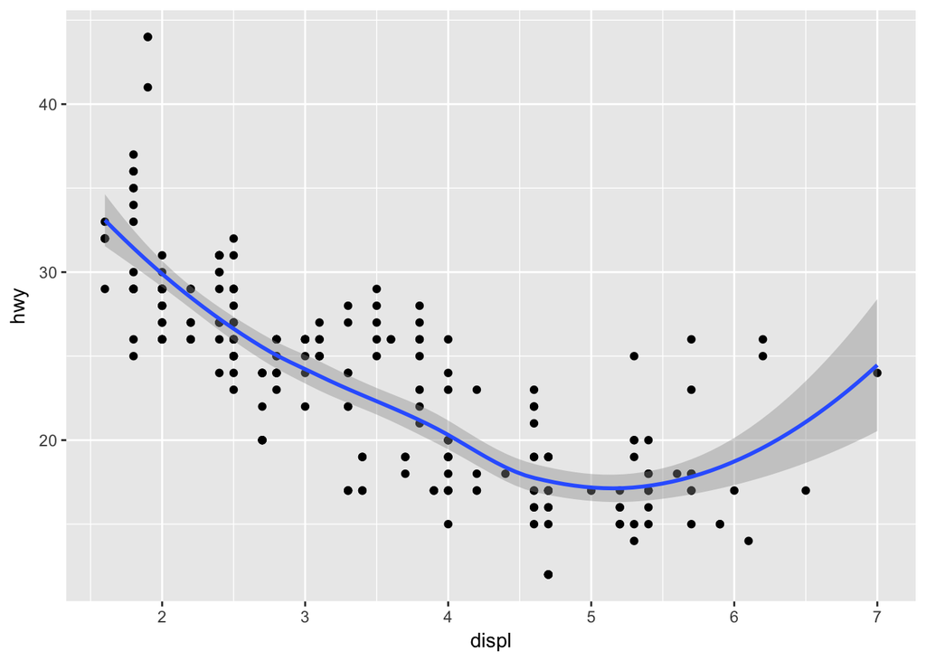

```r
ggplot(data = mpg, mapping = aes(x = displ, y = hwy)) +
  geom_point() +
  geom_smooth()
```

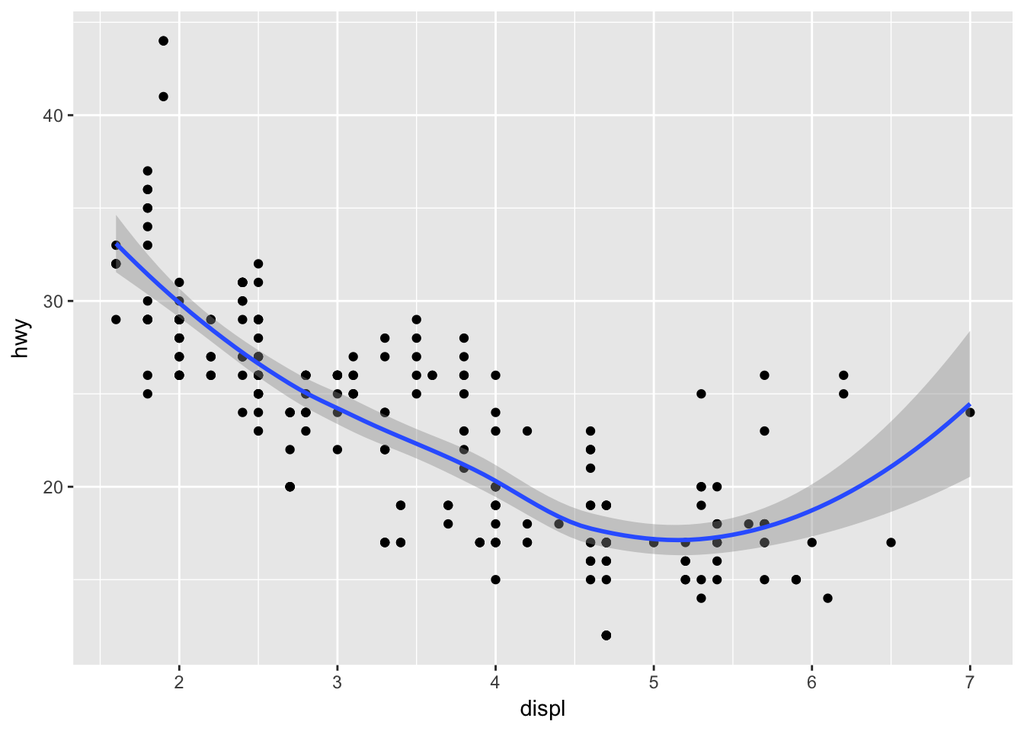

```r
ggplot() +
  geom_point(data = mpg, mapping = aes(x = displ, y = hwy)) +
  geom_smooth(data = mpg, mapping = aes(x = displ, y = hwy))
```

They look exactly the same to me.

### Section 3.7.1: #2 only

#### What does geom_col() do? How is it different to geom_bar()?

geom_col leaves the data as it is. geom_bar() creates two variables (count and prop) and then graphs the count data on the y axis. With geom_col you can plot the values of any x variable against any y variable.